# MTH 209 Data Manipulation and Management

Lesson 11: Object-Oriented Programming

Ying-Ju Tessa Chen  
ychen4@udayton.edu  
University of Dayton

# 4 Principles of Object-Oriented Programming

R is a functional programming language. However, R environment includes some support for object-oriented programming (OOP). Thus, R could be considered as an object-oriented language as it is based on the concept of “objects”. It can contain data and code. Many programmers believe that object-oriented programming can help us write clear and reusable code.

The four principles of object-oriented programming (OOP) are abstraction, encapsulation, inheritance, and polymorphism.

- Everything you touch in R is an object.
- Abstraction: Objects should only reveal internal mechanisms relevant for the use of other objects.
- Encapsulation: All information is contained inside an object, and only selected information is exposed. It helps you keep track of related variables, enhancing clarity.
- Inheritance: Classes can reuse code from other classes by designing relationships between them. This allows to extend a given class to a more specialized class.
- Polymorphism: Objects can take more than one form. It promotes reusability.

In this session, we will introduce two types of classes, S3 and S4.

**Note:** This lesson is based on the book: The Art of R Programming (Matloff (2011)).

# S3 Classes - 1

Most of R’s own built-in classes are of the S3 type. An S3 class consists of a list, with a class name attribute and dispatch capability added.

The functions that work with polymorphism, such as plot()and print(), are known as generic functions. When a generic function is called, R will dispatch the call to the proper class method, meaning that it will reroute the call to a function defined for the object’s class. Let’s use the lm() as an example.

```r
x <- 1:100
y <- 2*x + rnorm(100, 1, 10)
lm_model <- lm(y~x)
class(lm_model)
```

```
## [1] "lm"
```

```r
lm_model
```

```
##
## Call:
## lm(formula = y ~ x)
##
## Coefficients:
## (Intercept)            x
##      -1.500        2.047
```

R interpreter found that lm_model was an object of class “lm” and then called print.lm(), a special print method for the “lm” class.

# S3 Classes - 2

Let’s take a look at the generic function print() and the class method in this case.

```r
print
```

```
## function (x, ...)
## UseMethod("print")
## <bytecode: 0x000002c362bb6cd0>
## <environment: namespace:base>
```

We can see that print() consists solely of a call to UseMethod(), which is the dispatcher function. The printing depends on context, with a special print function called for the “lm” class.

# S3 Classes - 3

We can find all the implementations of a given generic method by calling methods(), like this:

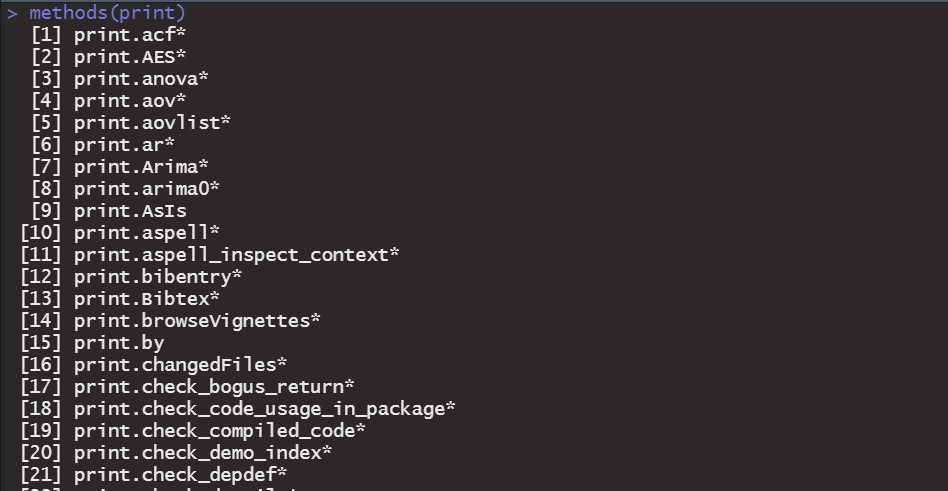

```r
methods(print)
```

# S3 Classes - 4

Asterisks denote non-visible functions, meaning ones that are not in the default namespaces. You can find these functions using the getAnywhere() function and then access them by using a namespace qualifier.

```r
getAnywhere(print.lm)
```

```
## A single object matching 'print.lm' was found
## It was found in the following places
##   registered S3 method for print from namespace stats
##   namespace:stats
## with value
##
## function (x, digits = max(3L, getOption("digits") - 3L), ...)
## {
##     cat("\nCall:\n", paste(deparse(x$call), sep = "\n", collapse = "\n"),
##         "\n\n", sep = "")
##     if (length(coef(x))) {
##         cat("Coefficients:\n")
##         print.default(format(coef(x), digits = digits), print.gap = 2L,
##             quote = FALSE)
##     }
##     else cat("No coefficients\n")
##     cat("\n")
##     invisible(x)
## }
## <bytecode: 0x000002c3634043e0>
## <environment: namespace:stats>
```

```
stats:::print.lm(lm_model)
```

You can see all the generic methods using the command methods(class=“default”).

# Writing S3 Classes - 1

S3 class has no formal, predefined definition. In general, a list with its class attribute set to some class name, is an S3 object. Here we show how to define a function that will create and return an object of a given class.

```r
info <- list(name = "Tessa", degree = "PhD", phone = 92405)
class(info) <- "instructor"
attributes(info)
```

```
## $names
## [1] "name"   "degree" "phone"
##
## $class
## [1] "instructor"
```

Before we write a print method for this class, let’s see what happens when we call the default print().

```r
info
```

```
## $name
## [1] "Tessa"
##
## $degree
## [1] "PhD"
##
## $phone
## [1] 92405
##
## attr(,"class")
## [1] "instructor"
```

# Writing S3 Classes - 2

Let’s write our own print method.

```r
print.instructor <- function(obj){
  cat(obj$name, "\n")
  cat("Degree: ", obj$degree, "\n")
  cat("UD Phone No:", obj$phone, "\n")
}
```

Now, any call to print() on an object of class “instructor” should now be referred to print.instructor().

```r
info
```

```
## Tessa
## Degree:  PhD
## UD Phone No: 92405
```

# Writing Our Own Generic Function

It is possible to make our own generic function like print() or plot().

For the sake of example, we make a new generic function called contact.

```r
contact <- function(obj){
  UseMethod("contact")
}
```

A generic function is useless without any method. Let us implement the default method.

```r
contact.default <- function(obj){
  cat("This is a generic function.\n")
}
```

Now let us make method for our class “instructor”.

```r
contact.instructor <- function(obj){
  cat(obj$name, "can be reached via", obj$phone, "\n")
}

contact(info)
```

```
## Tessa can be reached via 92405
```

# S4 Classes

S4 classes were developed later, with goal of adding safety, meaning that we cannot accidentally access a class component that is not already in existence.

The following table shows an overall of the differences between the two classes.

| Operation | S3 | S4 |
| --- | --- | --- |
| Define class | Implicit in constructor code | setClass() |
| Create object | Bulid list, set class attr | new() |
| Reference member variable | $ | @ |
| Implement generic f() | Define f.classname() | setMethod() |
| Declare generic | UseMethod() | setGeneric() |

# Writing S4 Classes - 1

We define an S4 class by calling setClass(). Continuing our instructor example, we can use the following code to define a new class, “instructor”, with three variables of specified types.

```r
setClass("instructor",
         representation(
           name = "character",
           degree = "character",
           phone = "numeric"
         )
)
```

Now let’s create an instance of this class, for Tessa, using new()

```r
tessa <- new("instructor", name = "Tessa", degree = "PhD", phone = 92405)
tessa
```

```
## An object of class "instructor"
## Slot "name":
## [1] "Tessa"
##
## Slot "degree":
## [1] "PhD"
##
## Slot "phone":
## [1] 92405
```

# Writing S4 Classes - 2

We note that the member variables are called *slots*, referenced via the @ symbol.

```r
tessa@degree
```

```
## [1] "PhD"
```

```r
slot(tessa, "degree")
```

```
## [1] "PhD"
```

```r
tessa@phone <- 12345
```

As noted, an advantage of using S4 is safety. Suppose we were to accidentally spell *phone” as “pone”. We can find that R will return an error message. By contrast, in S3 there would be no error message. S3 classes are just lists, and we are allowed to add a new component at any time.

```r
tessa@pone <- 92405
```

```
## Error in (function (cl, name, valueClass) : 'pone' is not a slot in class "instructor"
```

# Implementing a Generic Function on an S4 Class

We use setMethod() to define an implementation of a generic function on an S4 class. Let’s do that for our class “instructor” here. We will implement the show() function, which is the S4 analog of S3’s generic “print”.

```r
show(tessa)
```

```
## An object of class "instructor"
## Slot "name":
## [1] "Tessa"
##
## Slot "degree":
## [1] "PhD"
##
## Slot "phone":
## [1] 12345
```

Let’s override that, with the following code.

```r
setMethod("show", "instructor",
          function(obj){
            cat(obj@name, "can be reached via", obj@phone, "\n")
          }
)
tessa
```

```
## Tessa can be reached via 12345
```

The first argument gives the name of the generic function for which we will define a class-specific method, and the second argument gives the class name. Then we define a new function.

# Managing Our Objects - 1

There are various tools that can help to manage objects. Here are some useful functions.

- The ls() function: listing our objects

```r
ls()
```

```
##  [1] "contact"            "contact.default"    "contact.instructor"
##  [4] "df"                 "info"               "lm_model"
##  [7] "print.instructor"   "tessa"              "x"
## [10] "y"
```

```r
ls(pattern="te")
```

```
## [1] "tessa"
```

- The rm() function: remove specific objects

```r
rm(tessa)
rm(list = ls())
```

# Managing Our Objects - 2

- The save() function: saving a collection of objects

```r
x <- rnorm(1000, 100, 10)
hx <- hist(x)
```

```r
save(hx, file = "histogram_file")
ls()
```

```
## [1] "hx" "x"
```

```r
rm(hx)
ls()
```

```
## [1] "x"
```

# Managing Our Objects - 3

```r
load("histogram_file")
ls()
```

```
## [1] "hx" "x"
```

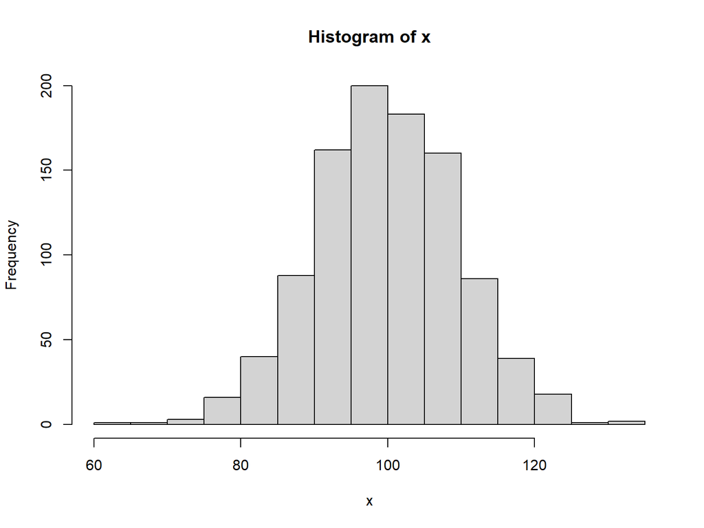

```r
plot(hx)
```

We use the save() function to save the object of class “histogram” to the file *histogram_file*. The object can be reloaded in that future session via load().

# Managing Our Objects - 4

Here we introduce some useful functions that help us to know the structure of an object.

- The class() function: checking the class of an object
- The mode() function: checking the storage mode of an object
- The names() function: getting the names of an object

```r
names(iris)
```

```
## [1] "Sepal.Length" "Sepal.Width"  "Petal.Length" "Petal.Width"  "Species"
```

- The attributes() function: getting the object attribute lists

```r
x <- cbind(a = 1:3, pi = pi) # simple matrix with dim names
attributes(x)
```

```
## $dim
## [1] 3 2
##
## $dimnames
## $dimnames[[1]]
## NULL
##
## $dimnames[[2]]
## [1] "a"  "pi"
```

# Managing Our Objects - 5

- The unclass() function: returning its argument with its class attribute removed
- The str() function: displaying the structure of an object
- The edit() function: invoking a text editor on an object
- The exists() function: checking whether the argument exists

```r
exists("hello")
```

```
## [1] FALSE
```

```r
exists("iris")
```

```
## [1] TRUE
```

# README

You can utilize the following single character keyboard shortcuts to enable alternate display modes (Xie, Allaire, and Grolemund (2018)):

- A: Switches show of current versus all slides (helpful for printing all pages)
- B: Make fonts large
- c: Show table of contents
- S: Make fonts smaller

Matloff, Norman. 2011. *The Art of r Programming: A Tour of Statistical Software Design*. No Starch Press.

Xie, Yihui, Joseph J Allaire, and Garrett Grolemund. 2018. *R Markdown: The Definitive Guide*. CRC Press.